# Vector and matrix math

2019-02-05

## Today's Agenda

- Review good programming practices
- Review R functions – for/next, if/else, while/loop
- Show some of the functions R has for matrix/vector operations

## Good Programming Practices

Most analysis will require some amount of programming. As we program, we should strive to create readable and reusable code. The art of creating good code is captured in the broad and opinionated topic of Good Programming Practices. You will devolop your own style, but it would be good to start with some guidance from some experts.

Google's R Style Guide https://google.github.io/styleguide/Rguide.xml  
Hadley Wickam's Style Guide: http://r-pkgs.had.co.nz/style.html

## Good Programming Practices cont

Remember: ultimate goal is Reproducible Research.  
To enable this, we need well documented (annotated) **readable** code.

1. variable/object names
   - nouns describing what the object holds, e.g. originaData instad of d
   - DO NOT use existing variables or functions, e.g. T<-1000
2. function formation
   - function names should be verb associated with the function purpose
   - comment both function purpose and required arguments
   - arguments should have defaults (my personal preference)
   - my preference is to explicitly return a value
3. commenting rules
   - comment your code!! 'nough said?
4. indent within logical blocks of code !!
   - indenting improves the readability of the code by orders of magnitude!

## Functions

A function is an **object** that takes some input objects (args) and produces some output objects.

```r
    dataA<-1;dataB<-2
    BAD<-function(x){
        mean(c(x,dataA))
    }
    computeMeanGOOD<-function(x=3,y=5){
        # quick function to compute the geometric mean of two numbers, x and y
        # returns geometric mean
        if (!is.numeric(x) || !is.numeric(y)) stop("both x and y must be numeric")
        return(mean(c(x,y)))
    }
    BAD(x=dataB)
    computeMeanGOOD(x=dataA,y=dataB)
```

GOOD functions include passing in ALL necessary data. If we do not do this, we can have MAJOR issues with variable scope that is often difficult to troubleshoot. Ideally our code also includes error checking.

**All** work in R is done in functions. '[<-'(animals,4,"duck")

## Variable scope

R uses Lexical scoping rules. What tha?

https://darrenjw.wordpress.com/2011/11/23/lexical-scope-and-function-closures-in-r/  
Totally recommend subscribing to Darren's blog AND reading all his past posts.

http://andrewgelman.com/2014/01/29/stupid-r-tricks-random-scope/  
Another good site. Also has a few great stats books.

While we are at it, r-bloggers has many useful tidbits. https://www.r-bloggers.com

```r
    z <- 1; a <- 1
    m <- function(){a <- 2; return(c(a,z)) }
    m(); a

    a <- 1; b <- 2
    f<-function(x){ a*x + b }
    ## what was this one
    g<-function(x){ a <<- 2; b <- 1; print(objects()); f(x) }
    g(2)
```

## FOR statement

Often, we want to loop through a set number of items or do a task a predetermined length of time. Can add additional controls via **break** and **next**. To get help on functions type ?"for"

```r
    Iter <- 5
    cumIndex <- 0
    for(i in 1:Iter){
        #if(i %% 2==1) next
        cumIndex <- cumIndex + 1
        #if(cumIndex>3) break
    }
    print(cumIndex)
```

```
## [1] 5
```

## If ELSE statement

A powerful addition to any program is the ability to change the course of the program as conditions change. In R, one such flow change statement is the if else statement.

```r
    Iter <- 20
    cumSumODDS <- 0
    cumSumEVENS <- 0
    for(i in 1:Iter){
        if(i %% 2 == 1){
            print(paste0("i=",i," is odd"))
            cumSumODDS = cumSumODDS + i
        }else{
            print(paste0("i=",i," is even"))
            cumSumEVENS = cumSumEVENS + i
        }
    }
```

```
## [1] "i=1 is odd"
## [1] "i=2 is even"
## [1] "i=3 is odd"
## [1] "i=4 is even"
## [1] "i=5 is odd"
## [1] "i=6 is even"
## [1] "i=7 is odd"
## [1] "i=8 is even"
## [1] "i=9 is odd"
## [1] "i=10 is even"
## [1] "i=11 is odd"
## [1] "i=12 is even"
## [1] "i=13 is odd"
## [1] "i=14 is even"
## [1] "i=15 is odd"
## [1] "i=16 is even"
## [1] "i=17 is odd"
## [1] "i=18 is even"
## [1] "i=19 is odd"
## [1] "i=20 is even"
```

```r
    cumSumEVENS
```

```
## [1] 110
```

```r
    cumSumODDS
```

```
## [1] 100
```

## While loop

A while loop can be thought of as a combination of a for loop and an if statement. Do until condition is true. In any iterative function, it is a good idea to a) have a progress indicator and b) have a fail safe.

```r
    dummyVar <- 0
    iter <- 0
    while(dummyVar<100){
        dummyVar = dummyVar + 1
        ## PROGRESS
        if(dummyVar %% 5 == 0){
            print(paste0("loop step=",dummyVar))
        }
        ## FAIL SAFE
        if(iter>50){
            break
        }else{
            iter=iter+1
        }
    }
```

```
## [1] "loop step=5"
## [1] "loop step=10"
## [1] "loop step=15"
## [1] "loop step=20"
## [1] "loop step=25"
## [1] "loop step=30"
## [1] "loop step=35"
## [1] "loop step=40"
## [1] "loop step=45"
## [1] "loop step=50"
```

## Timing

As you start to make functions, it is a good idea to think about how long things take.

Really good blog on this here: https://www.r-bloggers.com/5-ways-to-measure-running-time-of-r-code/

Consider the following code and timings:

```r
library("microbenchmark")
## takes a vector and a value, determines if the elements of the vector are
## to the right/left
left_right1 <- function(x = c(0.1, 0.9), bar = 0.5) {
    temp <- NULL
    for (i in seq_along(x)) {
        temp[i] <- (x[i] > bar) * 1
    }
    return(temp)
}
left_right2 <- function(x = c(0.1, 0.9), bar = 0.5) {
    ifelse(x > bar, 1, 0)
}
x1 <- rnorm(n = 50000, mean = 0.5)
times <- microbenchmark(result1 <- left_right1(x = x1), result2 <- left_right2(x = x1),
    times = 100, unit = "ms")
```

## Plot of timings

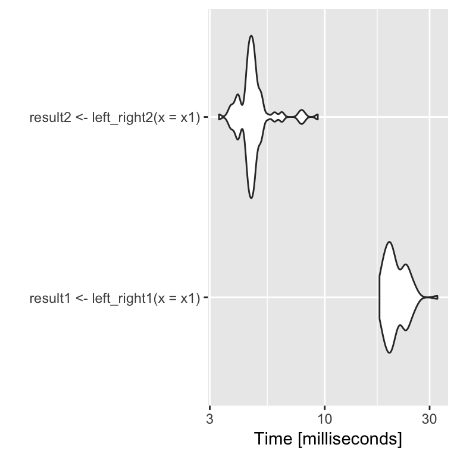

## What is your prediction for the following timings?

(run me!!)

```r
library(microbenchmark)

#manual vs internal mean function
microbenchmark(result1<-sum(1:10000)/10000,
               result2<-mean(1:10000),times = 100, unit = "ms")

#preallocate vs form on fly
temp<-rep(NULL,10000)
microbenchmark(result1<-{for(i in 1:length(temp)){temp[i]<-1}},
               result2<-{temp2<-rep(1,10000)},times = 100, unit = "ms")
```

## R and useful matrix stuff

1. matrix mult %*%
2. transpose t()
3. create diagonal matrix diag()
   - this one has two cases
4. matrix inverse solve()
5. determinate det()
6. rank matA <- qr(A); matA$rank
7. t(x) %*% y crossprod()

More comprehensive list here: https://www.statmethods.net/advstats/matrix.html